# Assignment 2

Mel Miller

9/21/2020

# Preparing the Dataset

To create my dataset to use for this assignment, I’ll first load the following libraries:

```r
library(ggplot2)
library(sf)
library(rnaturalearth)
library(tidyverse)
library(ggspatial)
library(cartogram)
library(ggthemes)
library (tidycensus)
library (tidyverse)
```

# Maps of States in the United States

For this assignment, I’ll use maps of mainland states in the United States, including the District of Columbia. I’ll provide a map of mainland United States below, and then I’ll create three different map projections of the United States.

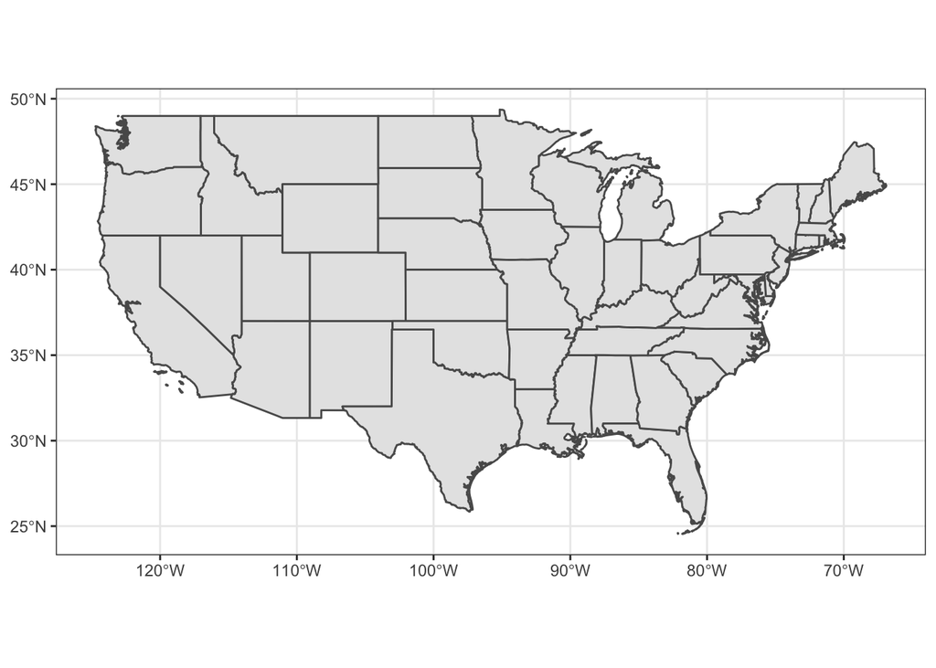

```r
US_states <- ne_states(country = "United States of America",
                       returnclass = "sf") %>%
  filter(name != "Alaska",
         name != "Hawaii")

US_map <- ggplot(US_states) +
  geom_sf() +
  theme_bw()

US_map
```

## Projection 1

This first projection uses the Albers Equal Area of the United States. I’ll use this map in the next section of this file when I map population data for older adults.

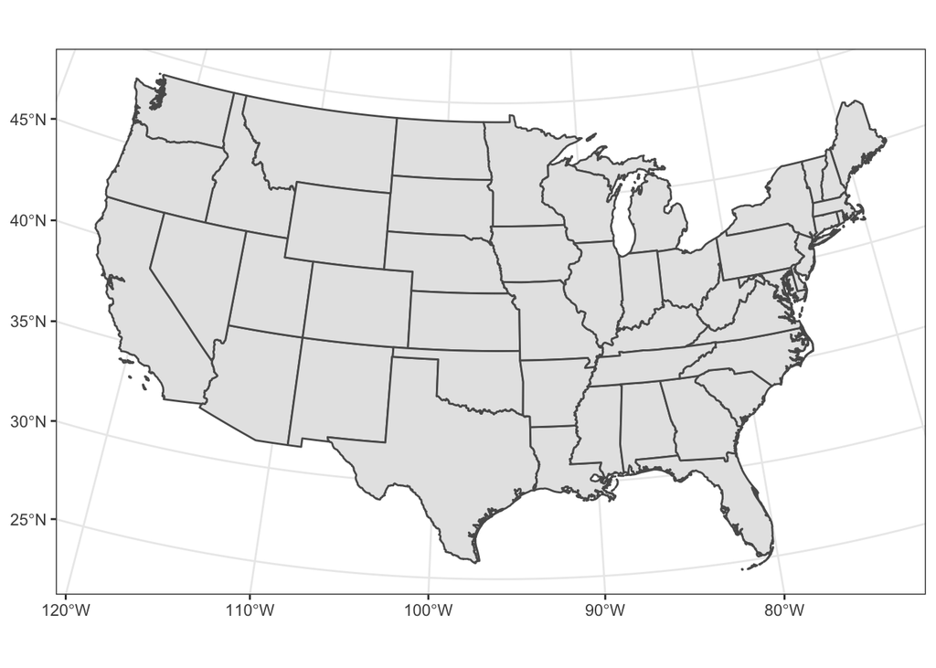

```r
USA_AEA <- "+proj=aea +lat_1=29.5 +lat_2=45.5 +lat_0=23 +lon_0=-96 +x_0=0 +y_0=0 +ellps=clrk66 +units=m +no_defs"

US_transformed <- US_states %>%
  st_transform(crs = USA_AEA)
ggplot(US_transformed) +
  geom_sf()+
  theme_bw()
```

## Projection 2

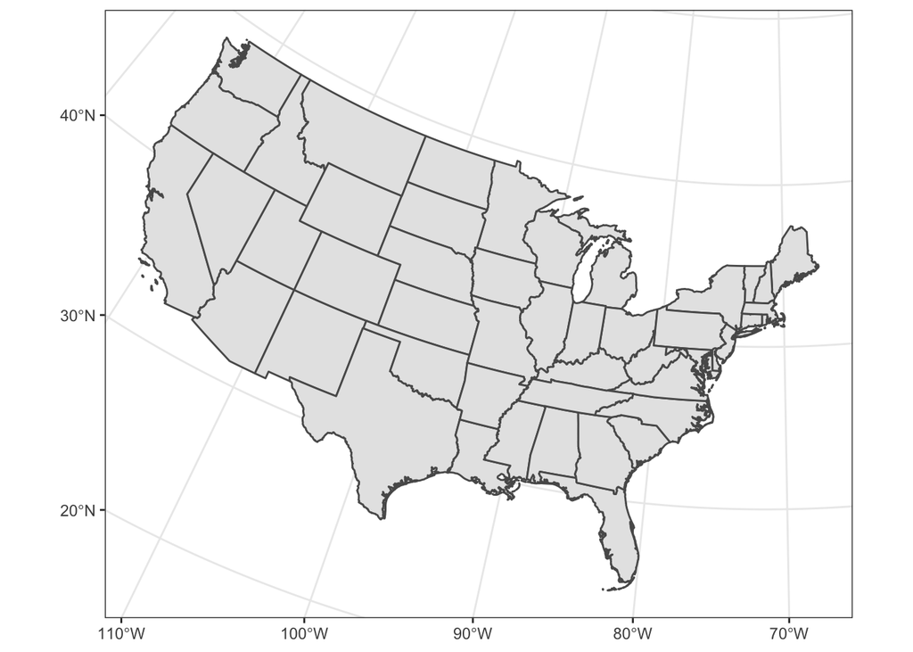

```r
MA_state_plane <- "+proj=lcc +lat_1=41.71666666666667 +lat_2=42.68333333333333 +lat_0=41 +lon_0=-71.5 +x_0=200000 +y_0=750000 +ellps=GRS80 +units=m +no_defs"

ggplot(US_states) +
  geom_sf() +
  coord_sf(crs = MA_state_plane) +
  theme_bw()
```

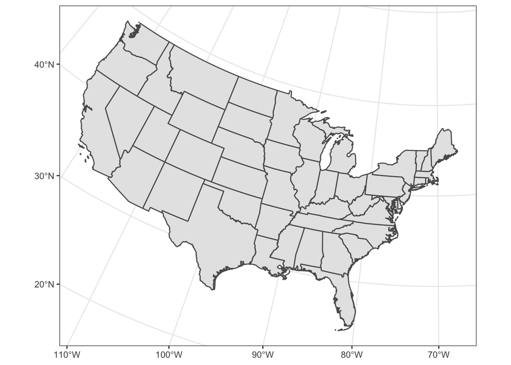

```r
MA_islands_stateplane <- "+proj=lcc +lat_1=41.28333333333333 +lat_2=41.48333333333333 +lat_0=41 +lon_0=-70.5 +x_0=200000 +y_0=750000 +ellps=GRS80 +units=m +no_defs"

ggplot(US_states) +
  geom_sf() +
  coord_sf(crs = MA_islands_stateplane) +
  theme_bw()
```

## Projection 3

This last projection uses the Hawaii Albers Equal Area Conic. Even though I did not include Hawaii in my map of the U.S., I was interested in how the map would transform when using Hawaii as a reference.

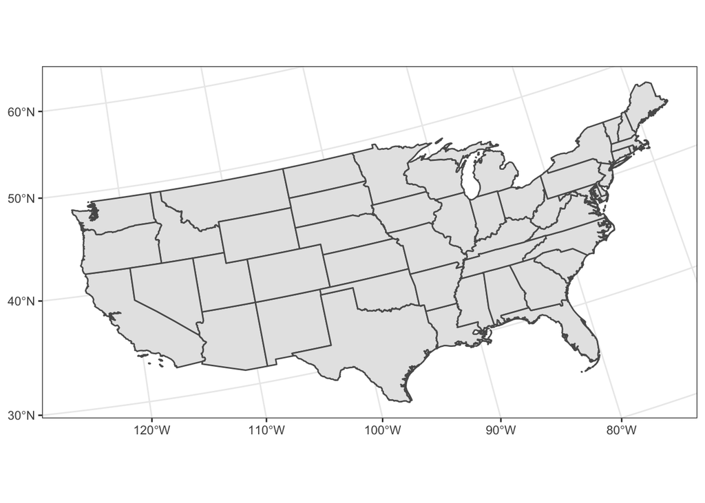

```r
HI_AEA_Conic <- "+proj=aea +lat_1=8 +lat_2=18 +lat_0=13 +lon_0=-157 +x_0=0 +y_0=0 +ellps=GRS80 +datum=NAD83 +units=m +no_defs"


ggplot(US_states) +
  geom_sf() +
  coord_sf(crs = HI_AEA_Conic) +
  theme_bw()
```

# Mapping Data

Next I’ll map data for the total population of older adults (65+) by state using data from the U.S. Census Bureau (2018).

```r
olderadults_us <- read_csv("2018 Cenus Data - Older Adults.csv")

olderadults_states <- US_transformed %>%
  left_join(olderadults_us, by = "name") %>%
  dplyr::select(name, OlderAdultPop, TotalPop)
```

## Chloropleth map

This Chloropleth map shows the total population of older adults by state. I think this map makes it clear just how many more older adults are living in California than any other state, and also how many states (33 to be exact) have less than 1 million people living there.

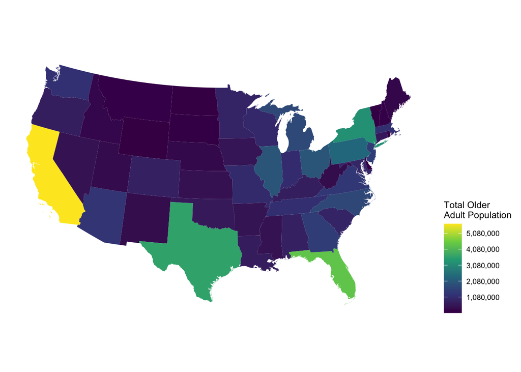

```r
 ggplot(olderadults_states, aes(fill = OlderAdultPop)) +
  geom_sf(color = NA) +
  scale_fill_viridis_c(name = "Total Older\nAdult Population",
    breaks = seq(80000, 6000000, by = 1000000),
    labels = formatC(seq(80000, 6000000, by = 1000000),
                     big.mark = ",", format = "f", digits = 0)) +
  theme_map() +
  theme(legend.background = element_blank())+
  theme(legend.position = "right")
```

## Proportional symbol map

This proportional symbol map uses circles to show proportional population size of older adults (e.g., the smallest circle represents the state with the smallest number of older adult residents). While I think this map communicates how few older adults live in Western and Midwestern states like Montana, Wyoming, North Dakota, and South Dakota, I do not think it provides a clear understanding of just how many older adults live in the Northeast, since these states are relatively small and close together.

```r
US_centeroids <- olderadults_states %>%
  st_centroid()
```

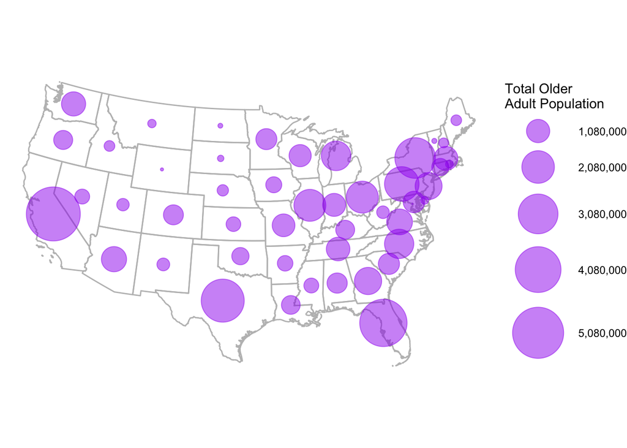

```r
ggplot(US_transformed) +
  geom_sf(fill = NA, color = "gray") +
  geom_sf(data = US_centeroids,
          aes(size = OlderAdultPop),
          alpha = 0.5, color = "purple") +
  scale_size_continuous(name = "Total Older\nAdult Population",
    breaks = seq(80000, 6000000, by = 1000000),
    labels = formatC(seq(80000, 6000000, by = 1000000),
                     big.mark = ",", format = "f", digits = 0),
    range = c(0, 20)) +
  theme_void()
```

## Non-continuous cartogram

This non-continuous cartogram distorts the sizes of the states in proportion to their total populations. I appreciate how this map better contextualizes the issue that I had with the previous map - for example, we see that Montana has a small older adult population, which is in line with its small total population.

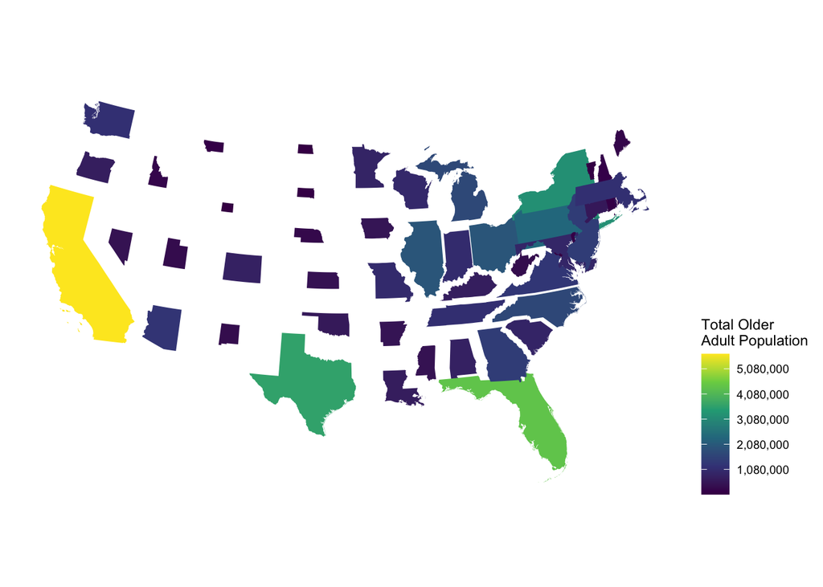

```r
US_cartogram_ncont <- olderadults_states %>%
  cartogram_ncont("TotalPop")

ggplot(US_cartogram_ncont, aes(fill = OlderAdultPop)) +
  geom_sf(color = NA) +
  scale_fill_viridis_c(
    name = "Total Older\nAdult Population",
    breaks = seq(80000, 6000000, by = 1000000),
    labels = formatC(seq(80000, 6000000, by = 1000000),
                     big.mark = ",", format = "f", digits = 0)) +
  theme_map() +
  theme(legend.background = element_blank())+
  theme(legend.position = "right")
```

*Acknowledgments: In completing this assignment, I referred to Carole’s tutorials. Alex also greatly assisted me in connecting my CSV file to the map data.*